# The Elo method in chess

**Elo method** was coined by the physics professor and excellent chess player Arpad Elo. In 1970, FIDE, the World Chess Federation, agreed to adopt the Elo Rating System.

The method works as follows. Suppose that players $i$ and $j$ match. Let $s_{i,j}$ be the **actual score** of $i$ in the match against $j$. We have that:

- $s_{i,j} = 1$ if $i$ wins;
- $s_{i,j} = 0$ if $i$ loses; and
- $s_{i,j} = 0.5$ if there is a draw.

Notice that the actual score $s_{j,i}$ of $j$ in the match against $i$ is $1 - s_{i,j}$. Let $\mu_{i,j}$ be the **expected score** of $i$ in the match against $j$. We have that:

$$\begin{array}{lll}
\mu_{i,j} & = & \frac{1}{1 + 10^{-(r_i - r_j) / \zeta}} =
\frac{10^{r_i / \zeta}}{10^{r_i / \zeta} + 10^{r_j / \zeta}} \\\\
\end{array}$$

with $r_i$ and $r_j$ the ratings of $i$ and $j$ before the match and $\zeta$ is a constant. Notice that the expected score $\mu_{j,i}$ of $j$ in the match against $i$ is $1 - \mu_{i,j}$.

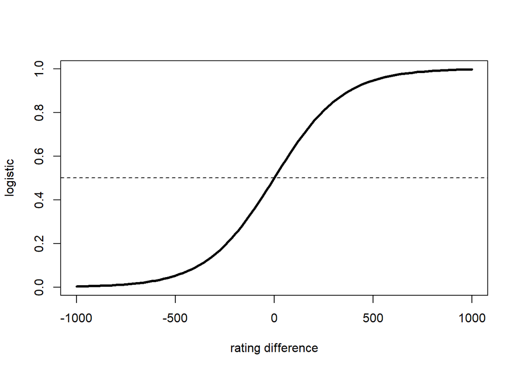

We assume that initially all player ratings are equal to 0. When players $i$ and $j$ match, the new ratings $r_i$ of $i$ and $r_j$ of $j$ are modified using the following update rule:

$$\begin{array}{lll}
r_{i} & \leftarrow & r_i + \kappa (s_{i,j} - \mu_{i,j})
\\
r_j & \leftarrow & r_j + \kappa (s_{j,i} - \mu_{j,i})
\end{array}$$

where $\kappa$ is a constant.

The Elo thesis is:

> *If a player performs as expected, it gains nothing. If it performs better than expected, it is rewarded, while if it performs poorer than expected, it is penalized.*

This challenge is ispired by [Chess ratings - Elo versus the Rest of the World](https://www.kaggle.com/c/chess#description) Kaggle competition.

## Downloads

- A CSV with outcomes of 65053 distinct chess games (White, Black and Score). The possible values for Score represent the three possible outcomes of a chess game (1=White wins, 0.5=draw, 0=Black wins). Read [details](https://www.kaggle.com/c/chess/data).

## Challenges

1. Has the White an advantage over the Black, that is, is there a first-mover advantage?
2. Write a function that computes the player point rating (1 point for wins, 0.5 points for draws, 0 points for defeats). How are point ratings distributed? Why?
3. An interesting property of Elo’s ratings is that the sum of all player ratings is always 0. Formally show this property. (Hint: use the fact that $s_{i,j} + s_{j,i}=1$ and $\mu_{i,j} + \mu_{j,i} =1$)
4. Write a function that computes the player Elo rating (set $\zeta = 400$ and $\kappa = 25$) (Hint: take advantage of the 0-sum property to optimize the code). Obserse its distribution: why is different from the point distribution? Verify the 0-sum property for Elo’s ratings
5. Are point and Elo ratings correlated? Are top Elo players overlapping with top point players?
6. Test if the number of played games has an effect on the Elo and point player ratings

### Setup

```r
library(readr)
library(dplyr)
library(tidyr)
library(ggplot2)

# File path compatible with both knitr render and interactive session
data_path <- if (file.exists("data.csv")) "data.csv" else "EloChess/data.csv"
games <- read_csv(data_path, show_col_types = FALSE)
```

### 1. First-Mover Advantage

```r
# Outcome counts and proportions
outcome_summary <- games |>
  mutate(Outcome = case_when(
    Score == 1   ~ "White",
    Score == 0.5 ~ "Draw",
    Score == 0   ~ "Black"
  )) |>
  count(Outcome, name = "Games") |>
  mutate(Percentage = round(100 * Games / sum(Games), 2))
outcome_summary
```

```
## # A tibble: 3 × 3
##   Outcome Games Percentage
##   <chr>   <int>      <dbl>
## 1 Black   15224       23.4
## 2 Draw    28666       44.1
## 3 White   21163       32.5
```

White wins **32.53%** of all games compared to **23.40%** for Black (with **44.07%** draws), showing a clear first move advantage.

### 2. Player Point Ratings and Their Distribution

```r
compute_point_ratings <- function(Games) {
  white_stats <- Games |>
    group_by(Player = White) |>
    summarise(Points_W = sum(Score), Games_W = n())

  black_stats <- Games |>
    group_by(Player = Black) |>
    summarise(Points_B = sum(1 - Score), Games_B = n())

  # Using coalesce to replacing NA values in case a player has never been white or black
  full_join(white_stats, black_stats, by = "Player") |>
    mutate(
      Points = coalesce(Points_W, 0) + coalesce(Points_B, 0),
      Games  = coalesce(Games_W, 0L) + coalesce(Games_B, 0L)
    ) |>
    select(Player, Points, Games) |>
    arrange(Player)
}

player_stats <- compute_point_ratings(games)
summary(player_stats)
```

```
##      Player         Points           Games
##  Min.   :   1   Min.   :  0.00   Min.   :  1.00
##  1st Qu.:2152   1st Qu.:  1.00   1st Qu.:  3.00
##  Median :4320   Median :  3.00   Median :  7.00
##  Mean   :4315   Mean   :  8.91   Mean   : 17.82
##  3rd Qu.:6463   3rd Qu.:  9.00   3rd Qu.: 20.00
##  Max.   :8631   Max.   :167.50   Max.   :280.00
```

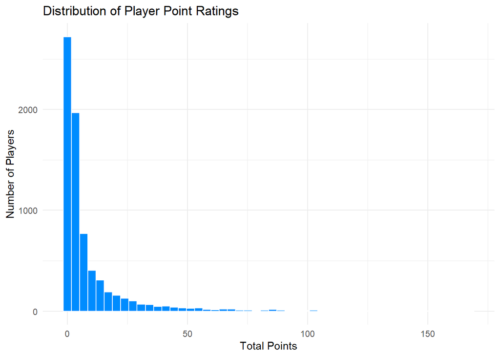

```r
ggplot(player_stats, aes(x = Points)) +
  geom_histogram(bins = 50, fill = "#008cff", color = "white") +
  labs(
    title = "Distribution of Player Point Ratings",
    x = "Total Points",
    y = "Number of Players"
  ) +
  theme_minimal()
```

**Why is the distribution shaped this way?** The point rating distribution is non-negative and **heavily right-skewed** (median = 3.0, mean = 8.91, maximum = 167.5). This happens for two reasons: 1. **Non-decreasing scoring:** Players never lose points for a defeat (0 points), while draws (+0.5) and wins (+1) strictly add to their total. 2. **Skewed participation:** Most players in the dataset compete in only a few games (median = 7 games), whereas a small subset of active players compete in hundreds of games (up to 280), accumulating large point totals.

### 3. The Zero-Sum Property of Elo Ratings

The Elo rating system acts like a closed system where points are neither created nor destroyed:

1. **Initial balance:** Every player starts with an initial rating of 0, so the total sum across all players begins at exactly 0.
2. **Complementary outcomes and expectations:** In any match between players $i$ and $j$, both the actual outcome and the expected score divide a total of 1 point ($s_{i,j} + s_{j,i} = 1$ and $\mu_{i,j} + \mu_{j,i} = 1$). Therefore, player $i$’s outperformance relative to expectations is identical to player $j$’s underperformance:
   $$(s_{i,j} - \mu_{i,j}) = -(s_{j,i} -
   \mu_{j,i})$$
3. **Zero net change per match:** Since rating adjustments are proportional to this difference, any rating points gained by player $i$ are subtracted from player $j$ in equal measure ($\Delta r_i = -\Delta r_j$).

Because every game is merely a zero-sum transfer between two opponents, the global sum never changes and remains strictly 0 after any number of games.

### 4. Player Elo Ratings, Distribution, and Zero-Sum Verification

Because $\Delta r_j = -\Delta r_i = -\kappa(s_{i,j} - \mu_{i,j})$, we only need to compute $\mu_{i,j}$ and $\Delta r_i$ once per game, adding $\Delta r_i$ to White’s rating and subtracting it from Black’s rating.

```r
compute_elo_ratings <- function(Games, zeta = 400, k = 25) {
  max_id <- max(c(Games$White, Games$Black))
  r <- numeric(max_id)

  white <- Games$White
  black <- Games$Black
  score <- Games$Score

  for (m in seq_len(nrow(Games))) {
    i <- white[m]
    j <- black[m]
    mu_ij <- 1 / (1 + 10^(-(r[i] - r[j]) / zeta))
    delta <- k * (score[m] - mu_ij)
    r[i] <- r[i] + delta
    r[j] <- r[j] - delta
  }

  tibble(
    Player = sort(unique(c(white, black))),
    Elo = r[Player]
  )
}

elo_df <- compute_elo_ratings(games, zeta = 400, k = 25)
player_stats <- player_stats |>
  left_join(elo_df, by = "Player")

summary(player_stats$Elo)
```

```
##     Min.  1st Qu.   Median     Mean  3rd Qu.     Max.
## -146.456  -22.873   -6.005    0.000   12.476  326.950
```

```r
# Verify the zero-sum property (up to floating-point precision)
sum_elo <- sum(player_stats$Elo)
cat("Sum of all Elo ratings:", sum_elo, "\n")
```

```
## Sum of all Elo ratings: 9.476309e-13
```

```r
all.equal(sum_elo, 0)
```

```
## [1] TRUE
```

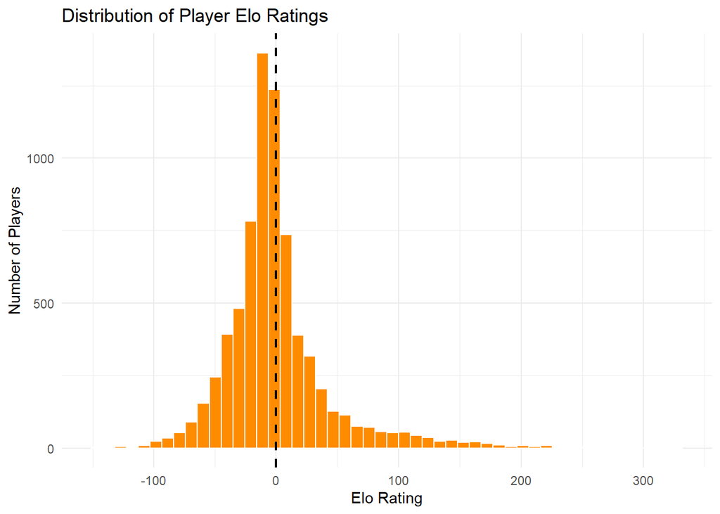

```r
ggplot(player_stats, aes(x = Elo)) +
  geom_histogram(bins = 50, fill = "#ff8c00", color = "white") +
  geom_vline(xintercept = 0, linetype = "dashed", linewidth = 0.8) +
  labs(
    title = "Distribution of Player Elo Ratings",
    x = "Elo Rating",
    y = "Number of Players"
  ) +
  theme_minimal()
```

**Why is the Elo distribution different from the point distribution?** Unlike cumulative points, the Elo distribution is **bell-shaped and centered around 0**. Because Elo is a zero-sum relative rating system that penalizes losses (and draws against weaker opponents) while scaling rewards by opponent strength, player ratings fluctuate both above and below the initial rating of $0$ rather than growing monotonically.

### 5. Correlation and Top-Player Overlap Between Point and Elo Ratings

We compute the linear correlation between `Points` and `Elo`, and check the overlap among top players using a simple `intersect()`.

```r
# Linear correlation
cat("Correlation (Points vs Elo):", round(cor(player_stats$Points, player_stats$Elo), 4), "\n")
```

```
## Correlation (Points vs Elo): 0.7199
```

```r
# Top 10 players comparison
top10_points <- head(player_stats$Player[order(-player_stats$Points)], 10)
top10_elo    <- head(player_stats$Player[order(-player_stats$Elo)], 10)

cat("Top 10 by Points:", top10_points, "\n")
```

```
## Top 10 by Points: 4037 1286 4850 1594 64 1098 391 1512 5050 2283
```

```r
cat("Top 10 by Elo:   ", top10_elo, "\n")
```

```
## Top 10 by Elo:    7848 3344 7715 2295 158 8121 2479 2581 8287 64
```

```r
cat("Overlapping players in Top 10:", intersect(top10_points, top10_elo), "\n")
```

```
## Overlapping players in Top 10: 64
```

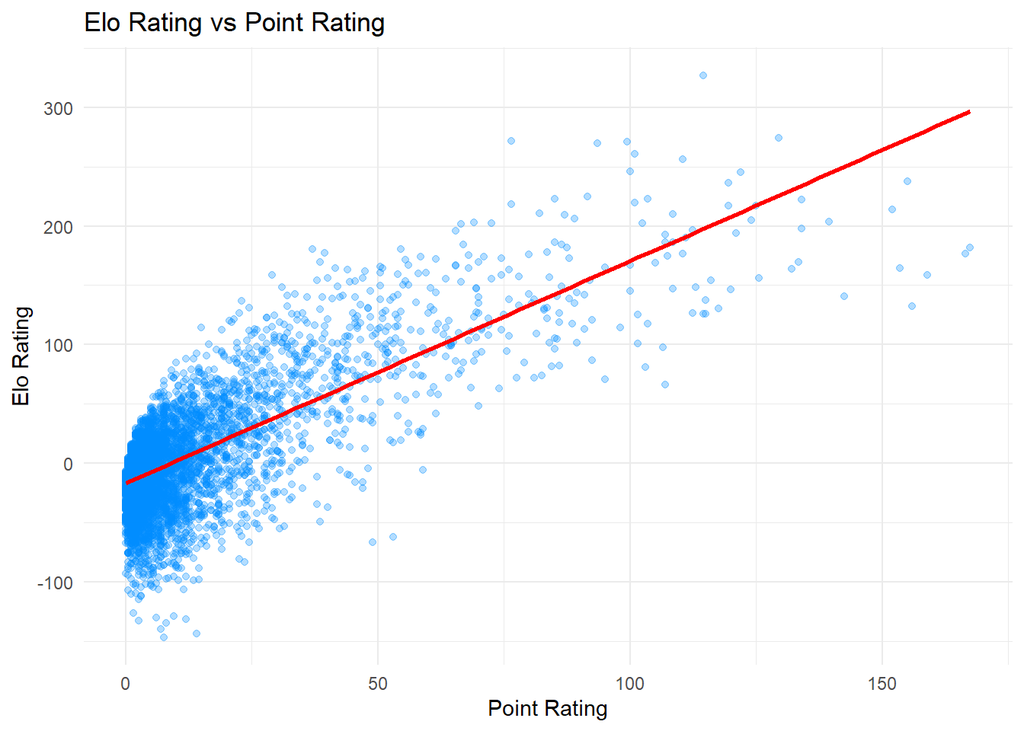

```r
# Scatter plot
ggplot(player_stats, aes(x = Points, y = Elo)) +
  geom_point(alpha = 0.3, color = "#008cff") +
  geom_smooth(method = "lm", color = "#ff0000", se = FALSE) +
  labs(
    title = "Elo Rating vs Point Rating",
    x = "Point Rating",
    y = "Elo Rating"
  ) +
  theme_minimal()
```

While Point and Elo ratings show a positive correlation ($r \approx 0.72$), there is very little overlap at the top of the leaderboard: only **1 player** (Player 64) appears in both Top 10 lists. Top point scorers are primarily those who played the most matches, whereas top Elo players achieved higher win rates against strong opponents in fewer matches.

### 6. Effect of the Number of Played Games on Elo and Point Ratings

To see how the number of played games affects player scores, we plot each player’s rating (y-axis) against their total games played (x-axis) for both metrics.

```r
# Simple correlations with games played
cat("Correlation (Games vs Points):", round(cor(player_stats$Games, player_stats$Points), 4), "\n")
```

```
## Correlation (Games vs Points): 0.9901
```

```r
cat("Correlation (Games vs Elo):   ", round(cor(player_stats$Games, player_stats$Elo), 4), "\n")
```

```
## Correlation (Games vs Elo):    0.6388
```

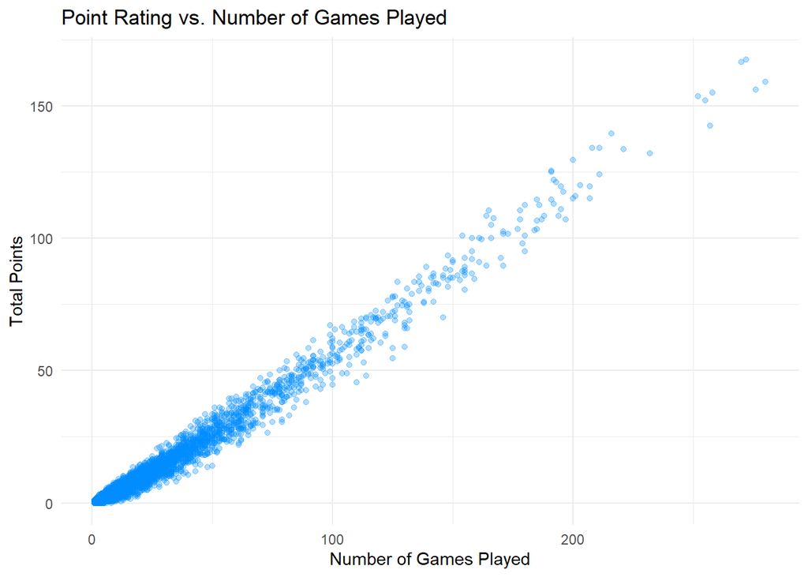

```r
# Plot 1: Points vs Games
ggplot(player_stats, aes(x = Games, y = Points)) +
  geom_point(alpha = 0.3, color = "#008cff") +
  labs(
    title = "Point Rating vs. Number of Games Played",
    x = "Number of Games Played",
    y = "Total Points"
  ) +
  theme_minimal()
```

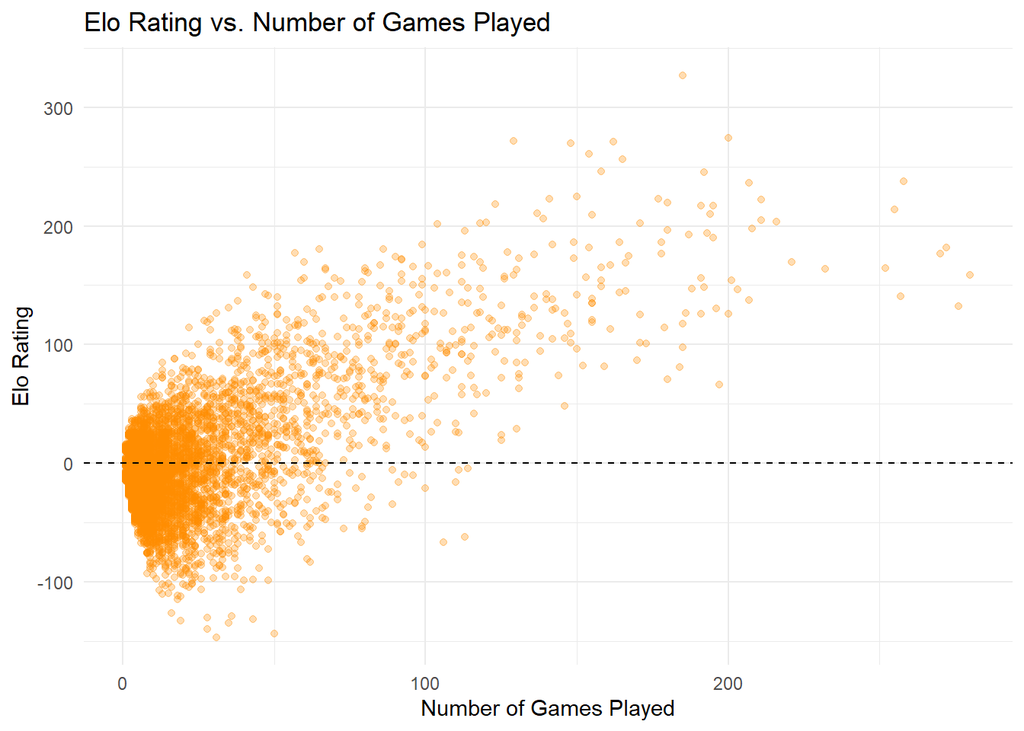

```r
# Plot 2: Elo vs Games
ggplot(player_stats, aes(x = Games, y = Elo)) +
  geom_point(alpha = 0.3, color = "#ff8c00") +
  geom_hline(yintercept = 0, linetype = "dashed") +
  labs(
    title = "Elo Rating vs. Number of Games Played",
    x = "Number of Games Played",
    y = "Elo Rating"
  ) +
  theme_minimal()
```

The two plots show clearly different behaviors: - **Points vs Games:** Points exhibit a nearly deterministic linear relationship ($r = 0.990$) with the number of games played: playing more games mechanically accumulates more points. - **Elo vs Games:** Elo ratings display a funnel-shaped pattern centered at 0. Although positive ($r = 0.639$) because top tournament players survive longer and play more rounds, high game volume does not guarantee a high Elo, as poor performances lead to negative ratings.